# GIS final exam practice-New York Evictions

Chung-En Tsern

16:21:26, 12 December, 2024

## Originality declaration

I, [** Chung-En Tsern **], confirm that the work presented in this assessment is my own. Where information has been derived from other sources, I confirm that this has been indicated in the work.

date: 12 December, 2024

## New York Evictions

New York City wish to conduct a study that aims to prevent people being evicted through understand possible related factors.You have been enlisted as a consultant and tasked to conduct an analysis of their data from 2020. You should use appropriate data processing and analysis methods to produce an overview report which summarises the patterns revealed in the data in this year. It is expected that at least some of the methods you use will relate to the spatial dimensions of the data. Your report should include a brief introduction including relevant contextual information at the beginning and a critical review of your findings at the end. You must include at least one map.

### Data

- List of evictions - https://data.cityofnewyork.us/City-Government/Evictions/6z8x-wfk4
- New York City community districts - https://data.cityofnewyork.us/City-Government/Community-Districts/yfnk-k7r4

## Initial project scope

### Background and Context

The evictions are frequently triggered by financial hardship or systemic inequalities, disproportionately affecting vulnerable populations. The consequences of evictions extend far beyond the immediate loss of housing, potentially challenges including homelessness and long-term economic instability. Given these implications, understanding eviction spatial and temporal patterns becomes paramount for developing informed policy-making strategies and implementing effective tenant protection measures.

### Data and Methodology

#### Data Sources

- NYC Eviction Records (2017-2024)
  - Key variables: execution dates, locations, Residential.Commercial
  - Initial data quality assessment needed for missing values (latitude and longitude)
- NYC Community Districts boundaries
  - Administrative boundaries for spatial analysis

### Limitations and Constraints

- Focus on 2020 may reflect unusual patterns due to COVID-19
- Variable constraints(income, race, etc.) may limit advanced statistical analyses

# Start your response here

##### Load packages

```r
library(spatstat) #spatial point processes
library(raster)
library(stars)
library(dplyr)
library(here)
library(sp)
library(tmap)
library(sf)
library(tmaptools)
library(stringr)
library(tidyverse)
library(fpc) #DBSCANg progress...
```

```r
evictions <- read.csv("Evictions_20241209.csv", na.strings = c("", "null"))
districts <- st_read("Community Districts.geojson")
summary(evictions)
```

```
##  Court.Index.Number Docket.Number    Eviction.Address
##  Length:100949      Min.   :     1   Length:100949
##  Class :character   1st Qu.: 29242   Class :character
##  Mode  :character   Median : 93540   Mode  :character
##                     Mean   :135070
##                     3rd Qu.:152900
##                     Max.   :496987
##
##  Eviction.Apartment.Number Executed.Date      Marshal.First.Name
##  Length:100949             Length:100949      Length:100949
##  Class :character          Class :character   Class :character
##  Mode  :character          Mode  :character   Mode  :character
##
##
##
##
##  Marshal.Last.Name  Residential.Commercial   BOROUGH          Eviction.Postcode
##  Length:100949      Length:100949          Length:100949      Min.   :    0
##  Class :character   Class :character       Class :character   1st Qu.:10453
##  Mode  :character   Mode  :character       Mode  :character   Median :10472
##                                                               Mean   :10783
##                                                               3rd Qu.:11226
##                                                               Max.   :14053
##
##   Ejectment         Eviction.Legal.Possession    Latitude       Longitude
##  Length:100949      Length:100949             Min.   :40.50   Min.   :-74.25
##  Class :character   Class :character          1st Qu.:40.67   1st Qu.:-73.95
##  Mode  :character   Mode  :character          Median :40.75   Median :-73.91
##                                               Mean   :40.75   Mean   :-73.91
##                                               3rd Qu.:40.84   3rd Qu.:-73.87
##                                               Max.   :40.91   Max.   :-73.70
##                                               NA's   :9092    NA's   :9092
##  Community.Board  Council.District  Census.Tract         BIN
##  Min.   : 1.000   Min.   : 1.0     Min.   :     1   Min.   :1000000
##  1st Qu.: 4.000   1st Qu.:12.0     1st Qu.:   197   1st Qu.:2009188
##  Median : 8.000   Median :19.0     Median :   374   Median :2129362
##  Mean   : 7.966   Mean   :23.8     Mean   :  8279   Mean   :2698948
##  3rd Qu.:12.000   3rd Qu.:37.0     3rd Qu.:   958   3rd Qu.:3339772
##  Max.   :18.000   Max.   :51.0     Max.   :157903   Max.   :5171959
##  NA's   :9092     NA's   :9092     NA's   :9092     NA's   :9338
##       BBL                NTA
##  Min.   :0.000e+00   Length:100949
##  1st Qu.:2.028e+09   Class :character
##  Median :2.060e+09   Mode  :character
##  Mean   :2.623e+09
##  3rd Qu.:3.072e+09
##  Max.   :5.080e+09
##  NA's   :9338
```

```r
sapply(evictions, function(x) sum(is.na(x)))
```

```
##        Court.Index.Number             Docket.Number          Eviction.Address
##                         0                         0                         0
## Eviction.Apartment.Number             Executed.Date        Marshal.First.Name
##                     15264                         0                         0
##         Marshal.Last.Name    Residential.Commercial                   BOROUGH
##                         0                         0                         0
##         Eviction.Postcode                 Ejectment Eviction.Legal.Possession
##                         0                         0                         0
##                  Latitude                 Longitude           Community.Board
##                      9092                      9092                      9092
##          Council.District              Census.Tract                       BIN
##                      9092                      9092                      9338
##                       BBL                       NTA
##                      9338                      9092
```

##### plot community district boundaries to check

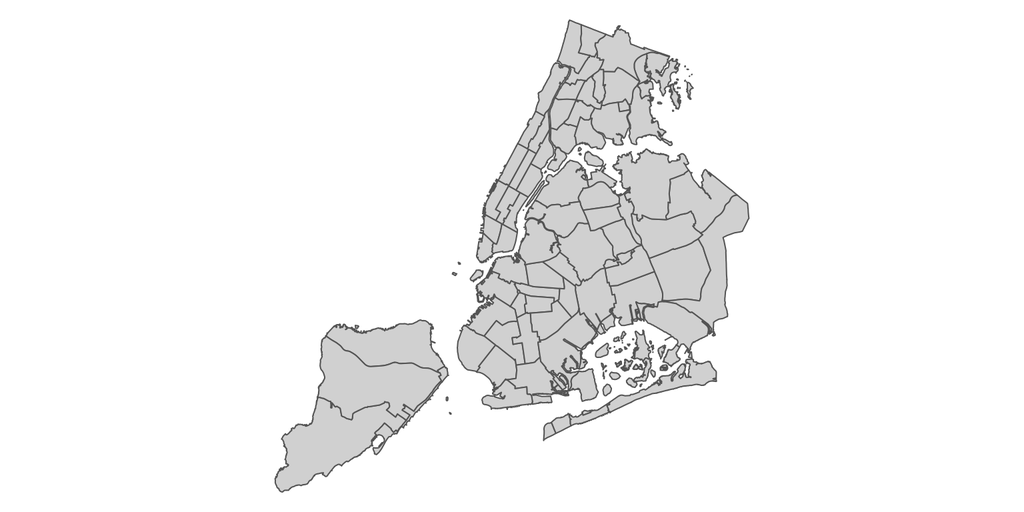

```r
tm_shape(districts) +
  tm_polygons() +
  tm_layout(frame = FALSE)
```

##### The first day is : 2017-01-03, The last day is : 2024-12-06 means I can analysis 7 years trend

```r
evictions$Executed.Date <- as.Date(evictions$Executed.Date, format = "%m/%d/%Y")

first_day = min(evictions$Executed.Date, na.rm = TRUE)
last_day = max(evictions$Executed.Date, na.rm = TRUE)

formatted_first_day = format(first_day, "%Y-%m-%d")
formatted_last_day = format(last_day, "%Y-%m-%d")

cat("The first day is :", formatted_first_day, "\n")
```

```
## The first day is : 2017-01-03
```

```r
cat("The last day is :", formatted_last_day, "\n")
```

```
## The last day is : 2024-12-06
```

##### plot monthly eviction counts from 2017 to 2024

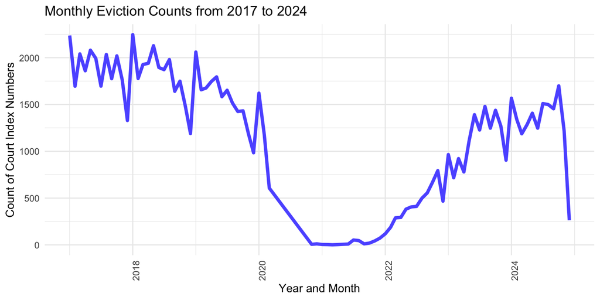

```r
evictions$YearMonth <- as.Date(paste0(format(as.Date(evictions$Executed.Date), "%Y-%m"), "-01"))

monthly_counts <- evictions %>%
  group_by(YearMonth) %>%
  summarise(Count = n(), .groups = 'drop')

ggplot(monthly_counts, aes(x = YearMonth, y = Count, group = 1)) +
  geom_line(size = 1.5, color = "#5e5eff") +
  labs(title = "Monthly Eviction Counts from 2017 to 2024",
       x = "Year and Month",
       y = "Count of Court Index Numbers") +
  theme_minimal() +
  theme(axis.text.x = element_text(angle = 90, hjust = 1))
```

##### plot annual eviction counts from 2017 to 2024

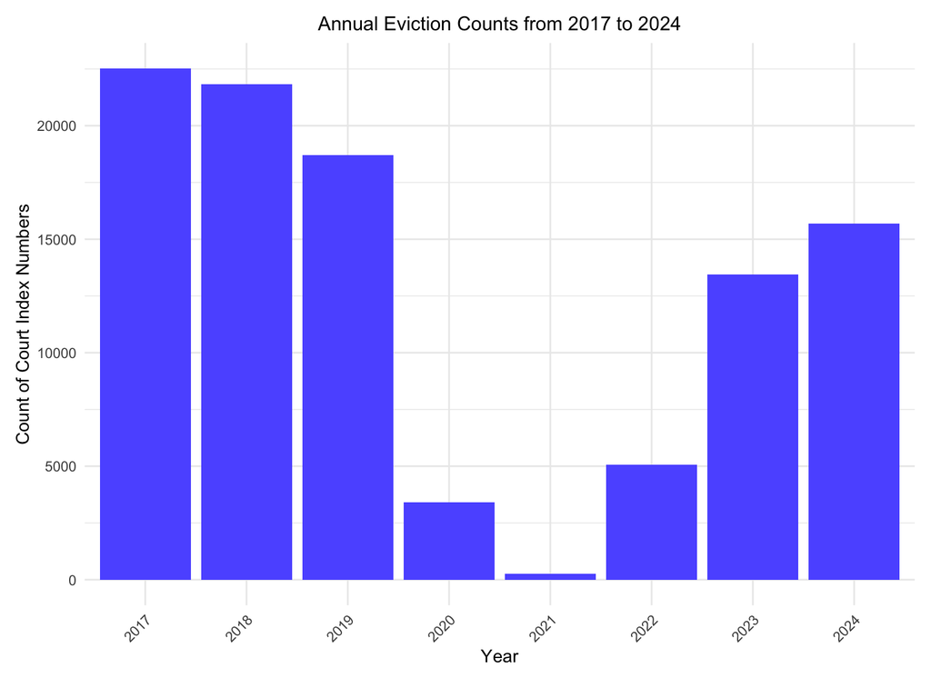

```r
evictions$Year <- format(as.Date(evictions$Executed.Date), "%Y")
annual_counts <- evictions %>%
  group_by(Year) %>%
  summarise(Count = n(), .groups = 'drop')

ggplot(annual_counts, aes(x = Year, y = Count)) +
  geom_col(fill = "#5e5eff") +
  labs(title = "Annual Eviction Counts from 2017 to 2024",
       x = "Year",
       y = "Count of Court Index Numbers") +
  theme_minimal() +
  theme(
    plot.title = element_text(hjust = 0.5, size = 12),
    axis.text.x = element_text(angle = 45, hjust = 1),
    plot.margin = margin(t = 10, r = 10, b = 20, l = 10)
  )
```

- The line and bar charts reveal significantly lower eviction numbers during 2020-2021 (COVID-19 period) compared to other years in our dataset. This notable decline suggests that 2020 may not be representative of typical eviction patterns, likely due to pandemic-related eviction moratoriums and other emergency housing policies. Therefore, we should exercise caution when interpreting this period’s data as it may not reflect normal eviction trends in New York City.

##### plot 2020 evictions by property type

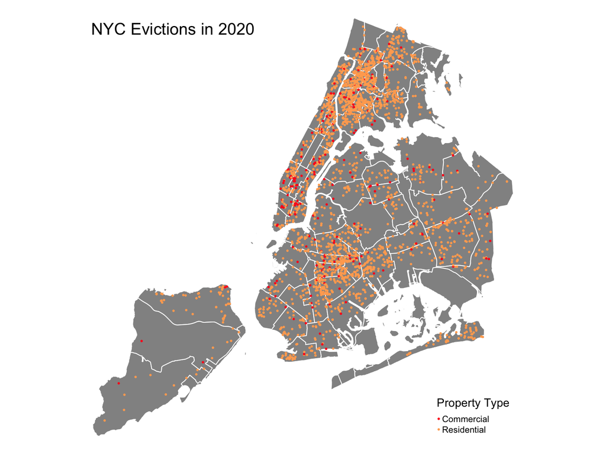

```r
# select 2020 data to analysis
evictions_2020 <- evictions[format(as.Date(evictions$Executed.Date), "%Y") == "2020", ]
evictions_2020_sf <- evictions_2020 %>%
  filter(!is.na(Latitude) & !is.na(Longitude)) %>%
  st_as_sf(coords = c("Longitude", "Latitude"),
           crs = 4326)
tm_shape(districts) +
  tm_polygons(col = "#000000",
              alpha = 0.5,
              border.col = "white") +
  tm_shape(evictions_2020_sf) +
  tm_dots(col = "Residential.Commercial",
          palette = c("#ff1c1c", "#ffaa5f"),
          size = 0.02,
          title = "Property Type") +
  tm_layout(title = "NYC Evictions in 2020",
           title.color = "#000000",
           legend.text.color = "#000000",
           legend.title.color = "#000000",
           legend.position = c("right", "bottom"),
           bg.color = "#ffffff",
           frame = FALSE)
```

- The map “NYC Evictions in 2020” highlights eviction events across New York City, categorized as Commercial (red) and Residential (orange). Evictions are concentrated in areas like Brooklyn, Bronx and Manhattan, with fewer cases in Staten Island and Queens. Commercial evictions are more prevalent in central business districts like Manhattan, while residential evictions are widespread, particularly in Brooklyn and the Bronx.

##### plot 2020 evictions by kernal density

```r
evictions_2020_projected <- st_transform(evictions_2020_sf, 32118) #New York State Plane East (meters)
districts_projected <- st_transform(districts, 32118)
gradient_color <- colorRampPalette(c("#ffffff", "#FEC44F", "#ff6600"))(5)


win <- as.owin(st_bbox(districts_projected))

# kernal density
pts <- st_coordinates(evictions_2020_projected)
ppp_obj <- ppp(pts[,1], pts[,2], window = win)
```

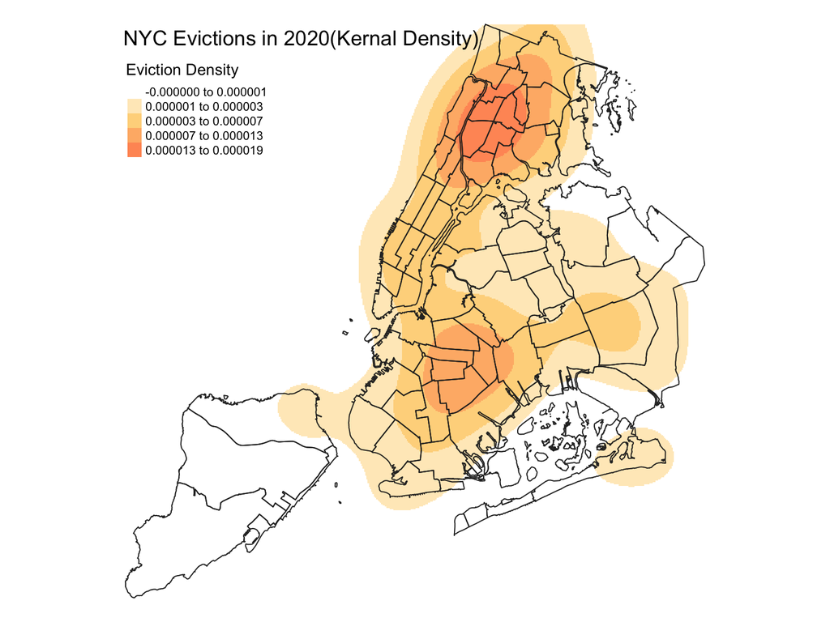

```r
kde <- density.ppp(ppp_obj,
                  sigma = 2000, # adjust smooth parameter
                  eps = c(100, 100)) # grid size

# convert to raster data
r <- raster(as.im(kde))
crs(r) <- st_crs(districts_projected)$wkt

# plot density map
tm_shape(districts_projected) +
  tm_borders(col = "#000000") +
  tm_shape(r) +
  tm_raster(palette = gradient_color,
            title = "Eviction Density",
            alpha = 0.7,
            style = "fisher") +
  tm_layout(title = "NYC Evictions in 2020(Kernal Density)",
            title.size = 1.2,
            frame = FALSE) +
  tm_shape(districts_projected) +
  tm_borders(col = "#2c2c2c", lwd = 1)
```

- The kernal density map provides a more detailed view of eviction density across NYC community districts. The highest eviction density is concentrated in Bronx area. These regions show the darkest orange shades, indicating significant housing pressures and the most frequent eviction cases in 2020.

##### plot 2020 evictions by DBSCAN

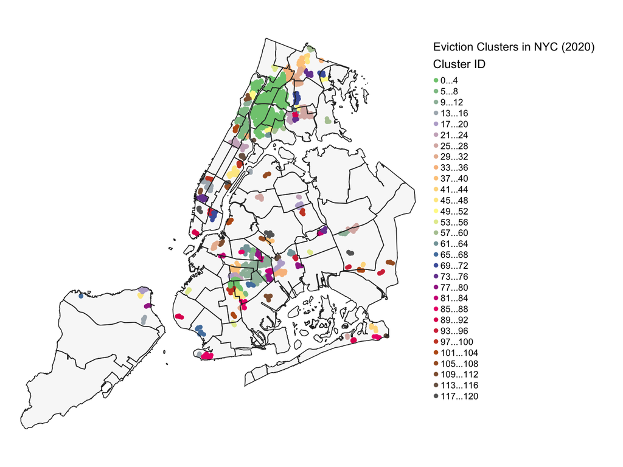

```r
#
coords <- st_coordinates(evictions_2020_projected)

dbscan_result <- dbscan(coords,
                       eps = 300, # search radius (meters)
                       MinPts = 5) # minimum points to form a cluster

# add cluster result to the original data
evictions_2020_clustered <- evictions_2020_projected %>%
  mutate(cluster = factor(dbscan_result$cluster))

# plot cluster map
tm_shape(districts_projected) +
  tm_polygons(col = "#f0f0f0",
              alpha = 0.5,
              border.col = "white") +
  tm_shape(evictions_2020_clustered %>%
           filter(cluster != 0)) + #filter cluster = 0
  tm_dots(col = "cluster",
          palette = "Accent",
          size = 0.1,
          title = "Cluster ID") +
  tm_layout(title = "Eviction Clusters in NYC (2020)",
           title.size = 1.2,
           frame = FALSE,
           legend.outside = TRUE)+
  tm_shape(districts_projected) +
  tm_borders(col = "#2c2c2c", lwd = 1)
```

```r
# calculate the number of each cluster
cluster_summary <- evictions_2020_clustered %>%
  st_drop_geometry() %>%
  group_by(cluster) %>%
  summarise(count = n()) %>%
  filter(cluster != 0) %>% # exclude noise points
  arrange(desc(count))

print(cluster_summary)
```

```
## # A tibble: 120 × 2
##    cluster count
##    <fct>   <int>
##  1 2         571
##  2 9         124
##  3 7          90
##  4 45         40
##  5 33         39
##  6 3          38
##  7 1          37
##  8 25         35
##  9 15         33
## 10 23         32
## # ℹ 110 more rows
```

- there are more than 100 clusters, so I only show the top 10 clusters

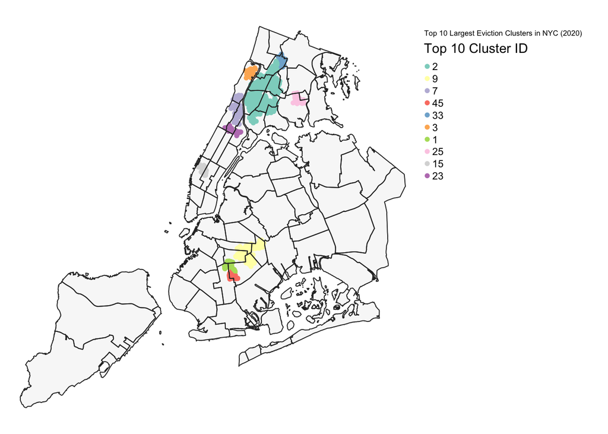

```r
top_10_clusters <- cluster_summary %>%
  head(10) %>%
  pull(cluster)

evictions_2020_top10 <- evictions_2020_clustered %>%
  filter(cluster %in% top_10_clusters) %>%
  mutate(cluster = factor(cluster, levels = top_10_clusters))

tm_shape(districts_projected) +
  tm_polygons(col = "#f0f0f0",
              alpha = 0.5,
              border.col = "white") +
  tm_shape(evictions_2020_top10) +
  tm_dots(col = "cluster",
          palette = "Set3",
          size = 0.1,
          title = "Top 10 Cluster ID") +
  tm_layout(title = "Top 10 Largest Eviction Clusters in NYC (2020)",
           title.size = 1.2,
           frame = FALSE,
           legend.outside = TRUE) +
  tm_shape(districts_projected) +
  tm_borders(col = "#2c2c2c", lwd = 1)
```

```r
print(head(cluster_summary, 10))
```

```
## # A tibble: 10 × 2
##    cluster count
##    <fct>   <int>
##  1 2         571
##  2 9         124
##  3 7          90
##  4 45         40
##  5 33         39
##  6 3          38
##  7 1          37
##  8 25         35
##  9 15         33
## 10 23         32
```

- The map highlights the top 10 eviction clusters in NYC (2020), with key hotspots in Upper Manhattan (e.g., Harlem), northern Brooklyn (e.g., Bedford-Stuyvesant), and the Bronx, reflecting areas of concentrated housing instability.

### Conclusion

- The analysis reveals that evictions are not evenly distributed across NYC community districts, with higher concentrations in certain areas. Commercial evictions are more prevalent in Manhattan, while residential evictions are widespread, particularly in Brooklyn and the Bronx. The kernal density map and DBSCAN clustering analysis provide a more detailed view of eviction density and clustering patterns, highlighting areas of concentrated housing instability. The NYC government should focus on the areas with high eviction density and clustering patterns to implement effective tenant protection measures.

### limitations

- The analysis is limited to 2020 data, which may not fully represent the typical eviction patterns in NYC.
- According to the annual eviction counts, the eviction rate continues to increase after 2021, which might change the eviction patterns.
- The analysis does not consider other factors that may influence eviction rates, such as income, race, and housing affordability.